# Composição/diversidade de comunidades de abelhas - Análise por Transectos

Unidade Amostral: Transectos (18 unidades) | 6 Locais × 3 Transectos

Cinthia Soares Novaes

28 de outubro de 2025

# 1 Introdução

## 1.1 Contexto

**⚠️ IMPORTANTE:** Esta análise utiliza **TRANSECTOS** como unidade amostral (n=18), não pontos individuais (n=54), para evitar pseudorreplicação.

**Estrutura hierárquica dos dados:**

```
6 Locais (IF, TM, MARM, SG, MV, CUR)
  └─ 3 Transectos por local (URB, TRAN, NAT)
      └─ 3 Pontos por transecto (agregados)
```

**Pergunta:** Como a composição e a diversidade de abelhas respondem à estrutura da paisagem, considerando a proporção de habitat natural e a heterogeneidade de usos e coberturas do solo?

**H1:** A diversidade e a composição de abelhas estão mais fortemente associadas à proporção de habitat natural, de modo que áreas com maior cobertura natural apresentam maior diversidade de espécies.

**H2:** Mosaicos de diferentes classes de uso e cobertura do solo oferecem recursos complementares que sustentam maior diversidade e mantêm comunidades distintas, tornando a heterogeneidade da paisagem um preditor mais importante.

**H0:** Não há associação significativa entre a proporção de habitat natural e a heterogeneidade da paisagem e os padrões de diversidade e composição de abelhas neste estudo.

## 1.2 Delineamento Amostral

- **6 locais** com diferentes contextos
  - **Urbanos:** TM, IF, MARM (bordas urbanas)
  - **Rurais:** CUR, SG, MV (zonas rurais)
- **3 transectos** por local (URB, TRAN, NAT)
- **3 pontos** por transecto (agregados para esta análise)
- **Total: 18 transectos** (unidades amostrais independentes)

## 1.3 Métodos Estatísticos

- **GLMM (Modelo Misto)**: Riqueza por transecto (n=18) com Local como efeito aleatório
- **NMDS**: Ordenação da composição de espécies por transecto
- **PERMANOVA**: Teste de efeito de variáveis ambientais (bloqueada por Local)
- **ANOSIM**: Diferenças entre grupos (contextos, locais e gradiente URB-TRAN-NAT)
- **IndVal e SIMPER**: Espécies indicadoras e contribuintes

# 2 Configuração Inicial

## 2.1 Carregar Pacotes

```r
library(tidyverse)
library(readxl)
library(vegan)
library(lme4)
library(lmerTest)  # Para p-valores em modelos mistos
library(MuMIn)
library(indicspecies)
library(ggplot2)
library(viridis)
library(gridExtra)
library(car)
library(scales)
```

## 2.2 Importar e Preparar Dados

```r
# Importar dados
# Forçando tipos de coluna para evitar erros de leitura
dados <- read_excel("../dados/Cap2.xlsx",
                    sheet = "Doc_Cinthia",
                    col_types = "text",  # Ler tudo como texto primeiro
                    .name_repair = "minimal")

# Limpeza inicial
dados <- dados %>%
  filter(
    Especie != "Vespa",
    Especie != "NA",
    !is.na(Especie),
    Especie != "Crabronidae sp.",
    Especie != "Xylocopa grisescens"
  ) %>%
  mutate(
    Especie = str_trim(Especie),
    # Converter colunas numéricas
    Area_Natural = as.numeric(Area_Natural),
    Area_Urbana = as.numeric(Area_Urbana),
    Pastagem = as.numeric(Pastagem),
    Mosaico_Usos = as.numeric(Mosaico_Usos),
    Areas_nao_veg. = as.numeric(Areas_nao_veg.),
    Mineracao = as.numeric(Mineracao),
    Lagos = as.numeric(Lagos),
    Lavouras_Temp. = as.numeric(Lavouras_Temp.),
    # Calcular total da paisagem
    total_paisagem = Area_Natural + Area_Urbana + Pastagem + Mosaico_Usos +
      Areas_nao_veg. + Mineracao + Lagos + Lavouras_Temp.,
    contexto = case_when(
      Local %in% c("TM_", "IF_", "MARM_") ~ "Borda_Urbana",
      Local %in% c("SG_", "MV_", "CUR_") ~ "Zona_Rural",
      TRUE ~ NA_character_
    )
  )

cat("📊 DADOS BRUTOS:\n")
```

```
## 📊 DADOS BRUTOS:
```

```r
cat("  - Total de registros:", nrow(dados), "\n")
```

```
##   - Total de registros: 1269
```

```r
cat("  - Número de espécies:", n_distinct(dados$Especie), "\n")
```

```
##   - Número de espécies: 41
```

```r
cat("  - Locais:", n_distinct(dados$Local), "\n")
```

```
##   - Locais: 6
```

```r
cat("  - Pontos individuais:", n_distinct(dados$Ponto), "\n")
```

```
##   - Pontos individuais: 54
```

## 2.3 Agregar por Transecto

```r
# Criar identificador de transecto único
dados <- dados %>%
  mutate(
    # Extrair tipo de transecto do nome do ponto
    tipo_transecto = case_when(
      str_detect(Ponto, "URB") ~ "URB",
      str_detect(Ponto, "TRAN") ~ "TRAN",
      str_detect(Ponto, "NAT") ~ "NAT",
      TRUE ~ NA_character_
    ),
    # ID único do transecto (ex: "IF_URB", "TM_TRAN")
    ID_transecto = paste0(str_remove(Local, "_$"), "_", tipo_transecto)
  )

# Verificar se todos os pontos foram classificados
cat("\n🔍 Verificação da classificação de transectos:\n")
```

```
##
## 🔍 Verificação da classificação de transectos:
```

```r
cat("  - Pontos com transecto identificado:",
    sum(!is.na(dados$tipo_transecto)), "/", nrow(dados), "\n")
```

```
##   - Pontos com transecto identificado: 1269 / 1269
```

```r
cat("  - Transectos únicos:", n_distinct(dados$ID_transecto, na.rm = TRUE), "\n\n")
```

```
##   - Transectos únicos: 18
```

```r
# Mostrar distribuição
cat("Distribuição por tipo de transecto:\n")
```

```
## Distribuição por tipo de transecto:
```

```r
print(table(dados$tipo_transecto, useNA = "ifany"))
```

```
##
##  NAT TRAN  URB
##  282  571  416
```

```r
cat("\nTransectos únicos identificados:\n")
```

```
##
## Transectos únicos identificados:
```

```r
print(sort(unique(dados$ID_transecto)))
```

```
##  [1] "CUR_NAT"   "CUR_TRAN"  "CUR_URB"   "IF_NAT"    "IF_TRAN"   "IF_URB"
##  [7] "MARM_NAT"  "MARM_TRAN" "MARM_URB"  "MV_NAT"    "MV_TRAN"   "MV_URB"
## [13] "SG_NAT"    "SG_TRAN"   "SG_URB"    "TM_NAT"    "TM_TRAN"   "TM_URB"
```

```r
# Remover registros sem transecto identificado (se houver)
dados <- dados %>% filter(!is.na(tipo_transecto))

cat("\n✅ Dados prontos para agregação por transecto\n")
```

```
##
## ✅ Dados prontos para agregação por transecto
```

```r
cat("   Total de registros válidos:", nrow(dados), "\n")
```

```
##    Total de registros válidos: 1269
```

# 3 Diversidade Alfa (GLMM - 18 transectos)

## 3.1 Calcular Riqueza e Abundância por Transecto

```r
# Agregar dados por transecto
riqueza_por_transecto <- dados %>%
  group_by(ID_transecto) %>%
  summarise(
    Local = first(str_remove(Local, "_$")),
    contexto = first(contexto),
    tipo_transecto = first(tipo_transecto),
    prop_hab_natural = first(Area_Natural) / first(total_paisagem),
    heterogeneidade = vegan::diversity(
      c(first(Area_Urbana), first(Pastagem), first(Mosaico_Usos),
        first(Areas_nao_veg.), first(Mineracao), first(Lagos),
        first(Lavouras_Temp.)),
      index = "shannon"
    ),
    riqueza = n_distinct(Especie),
    abundancia = n(),
    .groups = "drop"
  ) %>%
  mutate(
    # Ordenar fator para gradiente urbano → natural
    tipo_transecto = factor(tipo_transecto, levels = c("URB", "TRAN", "NAT"))
  )

cat("📊 RESUMO DA RIQUEZA POR TRANSECTO (n=18):\n\n")
```

```
## 📊 RESUMO DA RIQUEZA POR TRANSECTO (n=18):
```

```r
print(summary(riqueza_por_transecto))
```

```
##  ID_transecto          Local             contexto         tipo_transecto
##  Length:18          Length:18          Length:18          URB :6
##  Class :character   Class :character   Class :character   TRAN:6
##  Mode  :character   Mode  :character   Mode  :character   NAT :6
##
##
##
##  prop_hab_natural heterogeneidade     riqueza        abundancia
##  Min.   :0.4784   Min.   :0.4694   Min.   : 5.00   Min.   : 22.00
##  1st Qu.:0.6122   1st Qu.:0.6846   1st Qu.: 7.25   1st Qu.: 47.00
##  Median :0.6414   Median :1.0259   Median :11.00   Median : 57.50
##  Mean   :0.6997   Mean   :0.9481   Mean   :11.06   Mean   : 70.50
##  3rd Qu.:0.8817   3rd Qu.:1.1541   3rd Qu.:13.00   3rd Qu.: 91.25
##  Max.   :0.9433   Max.   :1.3284   Max.   :25.00   Max.   :150.00
```

```r
cat("\n📈 Estatísticas Descritivas:\n")
```

```
##
## 📈 Estatísticas Descritivas:
```

```r
cat("  - Riqueza média:", round(mean(riqueza_por_transecto$riqueza), 2), "±",
    round(sd(riqueza_por_transecto$riqueza), 2), "\n")
```

```
##   - Riqueza média: 11.06 ± 4.71
```

```r
cat("  - Riqueza mínima:", min(riqueza_por_transecto$riqueza), "\n")
```

```
##   - Riqueza mínima: 5
```

```r
cat("  - Riqueza máxima:", max(riqueza_por_transecto$riqueza), "\n")
```

```
##   - Riqueza máxima: 25
```

```r
cat("  - Abundância média:", round(mean(riqueza_por_transecto$abundancia), 2), "±",
    round(sd(riqueza_por_transecto$abundancia), 2), "\n")
```

```
##   - Abundância média: 70.5 ± 34.57
```

```r
# Tabela por contexto
cat("\n📋 Riqueza média por contexto:\n")
```

```
##
## 📋 Riqueza média por contexto:
```

```r
riqueza_por_transecto %>%
  group_by(contexto) %>%
  summarise(
    n_transectos = n(),
    riqueza_media = round(mean(riqueza), 2),
    riqueza_sd = round(sd(riqueza), 2),
    .groups = "drop"
  ) %>%
  print()
```

```
## # A tibble: 2 × 4
##   contexto     n_transectos riqueza_media riqueza_sd
##   <chr>               <int>         <dbl>      <dbl>
## 1 Borda_Urbana            9          8.89       2.47
## 2 Zona_Rural              9         13.2        5.52
```

```r
# Tabela por tipo de transecto
cat("\n📋 Riqueza média por tipo de transecto:\n")
```

```
##
## 📋 Riqueza média por tipo de transecto:
```

```r
riqueza_por_transecto %>%
  group_by(tipo_transecto) %>%
  summarise(
    n_transectos = n(),
    riqueza_media = round(mean(riqueza), 2),
    riqueza_sd = round(sd(riqueza), 2),
    .groups = "drop"
  ) %>%
  print()
```

```
## # A tibble: 3 × 4
##   tipo_transecto n_transectos riqueza_media riqueza_sd
##   <fct>                 <int>         <dbl>      <dbl>
## 1 URB                       6          11.7       2.42
## 2 TRAN                      6          13.5       6.35
## 3 NAT                       6           8         3.22
```

## 3.2 Modelos Lineares Generalizados Mistos (GLMM)

### 3.2.1 Seleção de Modelos

```r
cat("\n=== AJUSTANDO GLMMs (n=18 transectos) ===\n")
```

```
##
## === AJUSTANDO GLMMs (n=18 transectos) ===
```

```r
cat("Local incluído como efeito aleatório (1|Local) para controlar pseudorreplicação\n\n")
```

```
## Local incluído como efeito aleatório (1|Local) para controlar pseudorreplicação
```

```r
# Modelos candidatos
m1 <- glmer(riqueza ~ prop_hab_natural + (1|Local),
            data = riqueza_por_transecto,
            family = poisson,
            control = glmerControl(optimizer = "bobyqa"))

m2 <- glmer(riqueza ~ heterogeneidade + (1|Local),
            data = riqueza_por_transecto,
            family = poisson,
            control = glmerControl(optimizer = "bobyqa"))

m3 <- glmer(riqueza ~ prop_hab_natural + heterogeneidade + (1|Local),
            data = riqueza_por_transecto,
            family = poisson,
            control = glmerControl(optimizer = "bobyqa"))

m4 <- glmer(riqueza ~ prop_hab_natural * heterogeneidade + (1|Local),
            data = riqueza_por_transecto,
            family = poisson,
            control = glmerControl(optimizer = "bobyqa"))

m5 <- glmer(riqueza ~ tipo_transecto + (1|Local),
            data = riqueza_por_transecto,
            family = poisson,
            control = glmerControl(optimizer = "bobyqa"))

m6 <- glmer(riqueza ~ prop_hab_natural + tipo_transecto + (1|Local),
            data = riqueza_por_transecto,
            family = poisson,
            control = glmerControl(optimizer = "bobyqa"))

m7 <- glmer(riqueza ~ heterogeneidade + tipo_transecto + (1|Local),
            data = riqueza_por_transecto,
            family = poisson,
            control = glmerControl(optimizer = "bobyqa"))

m8 <- glmer(riqueza ~ (prop_hab_natural + heterogeneidade) * tipo_transecto + (1|Local),
            data = riqueza_por_transecto,
            family = poisson,
            control = glmerControl(optimizer = "bobyqa"))

# Comparar modelos
cat("Comparando modelos via AICc...\n\n")
```

```
## Comparando modelos via AICc...
```

```r
tabela_modelos <- model.sel(m1, m2, m3, m4, m5, m6, m7, m8)
print(tabela_modelos)
```

```
## Model selection table
##     (Int) prp_hab_ntr     htr htr:prp_hab_ntr tip_trn htr:tip_trn
## m5 2.4290                                           +
## m6 1.8110      0.8847                               +
## m7 2.7530             -0.3410                       +
## m1 1.7570      0.8847
## m2 2.6990             -0.3410
## m4 0.1511      4.0690  2.2780          -4.159
## m3 2.0950      0.9443 -0.3992
## m8 2.1860      0.6149 -0.1832                       +           +
##    prp_hab_ntr:tip_trn df  logLik  AICc delta weight
## m5                      4 -46.324 103.7  0.00  0.523
## m6                      5 -45.483 106.0  2.24  0.170
## m7                      5 -45.966 106.9  3.21  0.105
## m1                      3 -49.901 107.5  3.79  0.078
## m2                      3 -50.385 108.5  4.76  0.048
## m4                      5 -46.790 108.6  4.86  0.046
## m3                      4 -49.219 109.5  5.79  0.029
## m8                   + 10 -44.378 140.2 36.46  0.000
## Models ranked by AICc(x)
## Random terms (all models):
##   1 | Local
```

### 3.2.2 Melhor Modelo

```r
# Extrair melhor modelo
melhor_modelo <- get.models(tabela_modelos, subset = 1)[[1]]

cat("\n📊 MELHOR MODELO (menor AICc):\n")
```

```
##
## 📊 MELHOR MODELO (menor AICc):
```

```r
cat("Fórmula:", deparse(formula(melhor_modelo)), "\n")
```

```
## Fórmula: riqueza ~ tipo_transecto + (1 | Local)
```

```r
cat("AICc:", round(AICc(melhor_modelo), 2), "\n")
```

```
## AICc: 103.73
```

```r
cat("ΔAICc:", round(tabela_modelos$delta[1], 2), "\n\n")
```

```
## ΔAICc: 0
```

```r
# Mostrar coeficientes
cat("Efeitos fixos:\n")
```

```
## Efeitos fixos:
```

```r
print(summary(melhor_modelo)$coefficients)
```

```
##                      Estimate Std. Error    z value     Pr(>|z|)
## (Intercept)         2.4293569  0.1530618 15.8717381 9.944837e-57
## tipo_transectoTRAN  0.1459540  0.1626977  0.8970866 3.696727e-01
## tipo_transectoNAT  -0.3772944  0.1868340 -2.0194094 4.344468e-02
```

```r
cat("\n\nVariância do efeito aleatório (Local):\n")
```

```
##
##
## Variância do efeito aleatório (Local):
```

```r
print(VarCorr(melhor_modelo))
```

```
##  Groups Name        Std.Dev.
##  Local  (Intercept) 0.23109
```

```r
# ICC (Intraclass Correlation Coefficient)
var_local <- as.numeric(VarCorr(melhor_modelo)$Local[1])
var_residual <- pi^2/3  # Para Poisson
ICC <- var_local / (var_local + var_residual)
cat("\nICC (Correlação Intraclasse):", round(ICC, 3), "\n")
```

```
##
## ICC (Correlação Intraclasse): 0.016
```

```r
cat("Interpretação: ", round(ICC*100, 1), "% da variação está entre locais\n", sep="")
```

```
## Interpretação: 1.6% da variação está entre locais
```

```r
# Testar overdispersion
deviance_residual <- sum(residuals(melhor_modelo, type = "deviance")^2)
df_residual <- df.residual(melhor_modelo)
dispersion <- deviance_residual / df_residual

cat("\n🔍 Teste de Overdispersion:", round(dispersion, 3), "\n")
```

```
##
## 🔍 Teste de Overdispersion: 0.539
```

```r
if(dispersion > 1.5) {
  cat("⚠️ Overdispersion detectada (>1.5). Considere usar família Negative Binomial.\n")
} else {
  cat("✓ Sem problemas de overdispersion.\n")
}
```

```
## ✓ Sem problemas de overdispersion.
```

```r
# VIF (verificar colinearidade - só para modelos com 2+ preditores fixos)
# VIF precisa de pelo menos 2 preditores (além do intercepto)
n_fixef <- length(fixef(melhor_modelo))
if(n_fixef > 2) {  # Mais de 2 = intercepto + pelo menos 2 preditores
  cat("\n🔍 VIF (Colinearidade dos preditores):\n")
  cat("VIF > 3 indica colinearidade problemática\n\n")

  # Tentar calcular VIF com proteção contra erros
  vif_result <- tryCatch({
    vif(melhor_modelo)
  }, error = function(e) {
    cat("⚠️ Não foi possível calcular VIF (modelo pode ter apenas 1 preditor)\n")
    return(NULL)
  })

  if(!is.null(vif_result)) {
    print(vif_result)
    if(any(vif_result > 3)) {
      cat("\n⚠️ Atenção: VIF > 3 detectado para algum preditor\n")
    } else {
      cat("\n✓ Sem problemas de colinearidade (VIF < 3)\n")
    }
  }
} else {
  cat("\n✓ Modelo com apenas 1 preditor - VIF não necessário\n")
}
```

```
##
## 🔍 VIF (Colinearidade dos preditores):
## VIF > 3 indica colinearidade problemática
##
## ⚠️ Não foi possível calcular VIF (modelo pode ter apenas 1 preditor)
```

```r
# R² marginal e condicional
r2_values <- MuMIn::r.squaredGLMM(melhor_modelo)
cat("\n📊 R² do modelo:\n")
```

```
##
## 📊 R² do modelo:
```

```r
cat("  - R² marginal (efeitos fixos):", round(r2_values[1], 3), "\n")
```

```
##   - R² marginal (efeitos fixos): 0.263
```

```r
cat("  - R² condicional (fixos + aleatórios):", round(r2_values[2], 3), "\n")
```

```
##   - R² condicional (fixos + aleatórios): 0.269
```

### 3.2.3 Comparação com Modelos Competidores

```r
cat("\n=== MODELOS COMPETIDORES (ΔAICc < 2) ===\n\n")
```

```
##
## === MODELOS COMPETIDORES (ΔAICc < 2) ===
```

```r
modelos_competidores <- tabela_modelos %>%
  filter(delta < 2)

if(nrow(modelos_competidores) > 1) {
  cat("Número de modelos competidores:", nrow(modelos_competidores), "\n\n")

  # Selecionar apenas colunas que existem
  colunas_disponiveis <- intersect(c("df", "logLik", "AICc", "delta", "weight"),
                                   colnames(modelos_competidores))
  print(modelos_competidores[, colunas_disponiveis])

  cat("\n💡 Interpretação:\n")
  cat("  - Múltiplos modelos com ΔAICc < 2 sugerem incerteza sobre o melhor modelo\n")
  cat("  - Considere model averaging ou interpretar todos os modelos competidores\n")
} else {
  cat("✓ Apenas 1 modelo claramente melhor (ΔAICc > 2 para todos os outros)\n")
}
```

```
## ✓ Apenas 1 modelo claramente melhor (ΔAICc > 2 para todos os outros)
```

# 4 Análises Multivariadas (18 transectos)

## 4.1 Preparar Matrizes de Comunidade

```r
# Matriz de comunidade: transectos × espécies
matriz_comunidade_transectos <- dados %>%
  group_by(ID_transecto, Especie) %>%
  summarise(abundancia = n(), .groups = "drop") %>%
  pivot_wider(names_from = Especie, values_from = abundancia, values_fill = 0) %>%
  column_to_rownames("ID_transecto")

cat("📐 Dimensões da matriz de comunidade:\n")
```

```
## 📐 Dimensões da matriz de comunidade:
```

```r
cat("   ", nrow(matriz_comunidade_transectos), " transectos × ",
    ncol(matriz_comunidade_transectos), " espécies\n\n", sep = "")
```

```
##    18 transectos × 41 espécies
```

```r
# Verificar espécies raras
singletons <- colSums(matriz_comunidade_transectos > 0)
cat("Distribuição de frequência das espécies:\n")
```

```
## Distribuição de frequência das espécies:
```

```r
cat("  - Singletons (em apenas 1 transecto):", sum(singletons == 1), "\n")
```

```
##   - Singletons (em apenas 1 transecto): 12
```

```r
cat("  - Em 2-3 transectos:", sum(singletons >= 2 & singletons <= 3), "\n")
```

```
##   - Em 2-3 transectos: 11
```

```r
cat("  - Em 4+ transectos:", sum(singletons >= 4), "\n\n")
```

```
##   - Em 4+ transectos: 18
```

```r
# Variáveis ambientais por transecto
variaveis_transectos <- riqueza_por_transecto %>%
  select(ID_transecto, Local, contexto, tipo_transecto,
         prop_hab_natural, heterogeneidade) %>%
  column_to_rownames("ID_transecto")

# Verificar alinhamento
cat("✓ Alinhamento de matrizes:",
    all(rownames(matriz_comunidade_transectos) == rownames(variaveis_transectos)), "\n")
```

```
## ✓ Alinhamento de matrizes: TRUE
```

## 4.2 NMDS (Ordenação)

```r
cat("\n=== CALCULANDO NMDS ===\n")
```

```
##
## === CALCULANDO NMDS ===
```

```r
set.seed(123)
nmds_transectos <- metaMDS(matriz_comunidade_transectos,
                           distance = "bray",
                           k = 2,
                           trymax = 100,
                           trace = FALSE)

cat("📊 Stress do NMDS (k=2):", round(nmds_transectos$stress, 4), "\n\n")
```

```
## 📊 Stress do NMDS (k=2): 0.1442
```

```r
cat("Interpretação do Stress:\n")
```

```
## Interpretação do Stress:
```

```r
cat("  < 0.05: Excelente\n")
```

```
##   < 0.05: Excelente
```

```r
cat("  0.05-0.10: Ótimo\n")
```

```
##   0.05-0.10: Ótimo
```

```r
cat("  0.10-0.20: Bom\n")
```

```
##   0.10-0.20: Bom
```

```r
cat("  > 0.20: Regular/Ruim\n\n")
```

```
##   > 0.20: Regular/Ruim
```

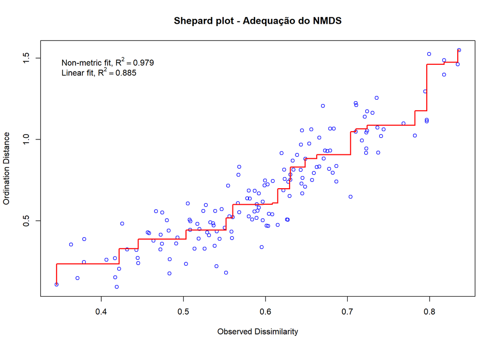

```r
# Teste de adequação (Shepard plot)
stressplot(nmds_transectos, main = "Shepard plot - Adequação do NMDS")
```

```r
# Se stress alto, tentar k=3
if(nmds_transectos$stress > 0.20) {
  cat("\n⚠️ Stress alto! Tentando k=3...\n")
  nmds_transectos_3d <- metaMDS(matriz_comunidade_transectos,
                                distance = "bray",
                                k = 3,
                                trymax = 100,
                                trace = FALSE)
  cat("✓ Novo stress (k=3):", round(nmds_transectos_3d$stress, 4), "\n")

  if(nmds_transectos_3d$stress < nmds_transectos$stress) {
    cat("  → k=3 tem melhor ajuste. Considere usar esse modelo.\n")
  }
}
```

## 4.3 PERMANOVA

```r
cat("\n\n=== PERMANOVA (n=18 transectos) ===\n")
```

```
##
##
## === PERMANOVA (n=18 transectos) ===
```

```r
# Modelo 1: Variáveis contínuas
perm1 <- adonis2(matriz_comunidade_transectos ~ prop_hab_natural + heterogeneidade,
                 data = variaveis_transectos,
                 permutations = 999,
                 method = "bray")

# Modelo 2: + Contexto
perm2 <- adonis2(matriz_comunidade_transectos ~ prop_hab_natural + heterogeneidade + contexto,
                 data = variaveis_transectos,
                 permutations = 999,
                 method = "bray")

# Modelo 3: + Tipo de transecto
perm3 <- adonis2(matriz_comunidade_transectos ~ prop_hab_natural + heterogeneidade + tipo_transecto,
                 data = variaveis_transectos,
                 permutations = 999,
                 method = "bray")

# Modelo 4: Gradiente URB→TRAN→NAT
perm4 <- adonis2(matriz_comunidade_transectos ~ tipo_transecto,
                 data = variaveis_transectos,
                 permutations = 999,
                 method = "bray")

# Modelo 5: BLOQUEADA por Local (controla pseudorreplicação) ⭐
perm_blocked <- adonis2(matriz_comunidade_transectos ~ prop_hab_natural + heterogeneidade,
                        data = variaveis_transectos,
                        permutations = 999,
                        method = "bray",
                        strata = variaveis_transectos$Local)

# Modelo 6: Gradiente bloqueado por Local
perm_gradiente_blocked <- adonis2(matriz_comunidade_transectos ~ tipo_transecto,
                                  data = variaveis_transectos,
                                  permutations = 999,
                                  method = "bray",
                                  strata = variaveis_transectos$Local)

cat("\n--- MODELO 1: Habitat + Heterogeneidade ---\n")
```

```
##
## --- MODELO 1: Habitat + Heterogeneidade ---
```

```r
print(perm1)
```

```
## Permutation test for adonis under reduced model
## Permutation: free
## Number of permutations: 999
##
## adonis2(formula = matriz_comunidade_transectos ~ prop_hab_natural + heterogeneidade, data = variaveis_transectos, permutations = 999, method = "bray")
##          Df SumOfSqs      R2     F Pr(>F)
## Model     2   0.5333 0.27774 2.884  0.008 **
## Residual 15   1.3869 0.72226
## Total    17   1.9202 1.00000
## ---
## Signif. codes:  0 '***' 0.001 '**' 0.01 '*' 0.05 '.' 0.1 ' ' 1
```

```r
cat("\n--- MODELO 2: + Contexto ---\n")
```

```
##
## --- MODELO 2: + Contexto ---
```

```r
print(perm2)
```

```
## Permutation test for adonis under reduced model
## Permutation: free
## Number of permutations: 999
##
## adonis2(formula = matriz_comunidade_transectos ~ prop_hab_natural + heterogeneidade + contexto, data = variaveis_transectos, permutations = 999, method = "bray")
##          Df SumOfSqs      R2      F Pr(>F)
## Model     3   0.6695 0.34867 2.4981  0.008 **
## Residual 14   1.2507 0.65133
## Total    17   1.9202 1.00000
## ---
## Signif. codes:  0 '***' 0.001 '**' 0.01 '*' 0.05 '.' 0.1 ' ' 1
```

```r
cat("\n--- MODELO 3: + Tipo de Transecto ---\n")
```

```
##
## --- MODELO 3: + Tipo de Transecto ---
```

```r
print(perm3)
```

```
## Permutation test for adonis under reduced model
## Permutation: free
## Number of permutations: 999
##
## adonis2(formula = matriz_comunidade_transectos ~ prop_hab_natural + heterogeneidade + tipo_transecto, data = variaveis_transectos, permutations = 999, method = "bray")
##          Df SumOfSqs      R2      F Pr(>F)
## Model     4  0.89183 0.46446 2.8186  0.001 ***
## Residual 13  1.02833 0.53554
## Total    17  1.92016 1.00000
## ---
## Signif. codes:  0 '***' 0.001 '**' 0.01 '*' 0.05 '.' 0.1 ' ' 1
```

```r
cat("\n--- MODELO 4: Apenas Gradiente URB→TRAN→NAT ---\n")
```

```
##
## --- MODELO 4: Apenas Gradiente URB→TRAN→NAT ---
```

```r
print(perm4)
```

```
## Permutation test for adonis under reduced model
## Permutation: free
## Number of permutations: 999
##
## adonis2(formula = matriz_comunidade_transectos ~ tipo_transecto, data = variaveis_transectos, permutations = 999, method = "bray")
##          Df SumOfSqs      R2      F Pr(>F)
## Model     2  0.35853 0.18672 1.7219  0.093 .
## Residual 15  1.56163 0.81328
## Total    17  1.92016 1.00000
## ---
## Signif. codes:  0 '***' 0.001 '**' 0.01 '*' 0.05 '.' 0.1 ' ' 1
```

```r
cat("\n--- MODELO 5: Habitat + Heterog. BLOQUEADO (Local) ⭐ ---\n")
```

```
##
## --- MODELO 5: Habitat + Heterog. BLOQUEADO (Local) ⭐ ---
```

```r
print(perm_blocked)
```

```
## Permutation test for adonis under reduced model
## Blocks:  strata
## Permutation: free
## Number of permutations: 999
##
## adonis2(formula = matriz_comunidade_transectos ~ prop_hab_natural + heterogeneidade, data = variaveis_transectos, permutations = 999, method = "bray", strata = variaveis_transectos$Local)
##          Df SumOfSqs      R2     F Pr(>F)
## Model     2   0.5333 0.27774 2.884      1
## Residual 15   1.3869 0.72226
## Total    17   1.9202 1.00000
```

```r
cat("\n--- MODELO 6: Gradiente BLOQUEADO (Local) ⭐ ---\n")
```

```
##
## --- MODELO 6: Gradiente BLOQUEADO (Local) ⭐ ---
```

```r
print(perm_gradiente_blocked)
```

```
## Permutation test for adonis under reduced model
## Blocks:  strata
## Permutation: free
## Number of permutations: 999
##
## adonis2(formula = matriz_comunidade_transectos ~ tipo_transecto, data = variaveis_transectos, permutations = 999, method = "bray", strata = variaveis_transectos$Local)
##          Df SumOfSqs      R2      F Pr(>F)
## Model     2  0.35853 0.18672 1.7219  0.005 **
## Residual 15  1.56163 0.81328
## Total    17  1.92016 1.00000
## ---
## Signif. codes:  0 '***' 0.001 '**' 0.01 '*' 0.05 '.' 0.1 ' ' 1
```

```r
cat("\n\n💡 INTERPRETAÇÃO:\n")
```

```
##
##
## 💡 INTERPRETAÇÃO:
```

```r
cat("  - Modelos bloqueados controlam a não-independência dos 3 transectos dentro de cada local\n")
```

```
##   - Modelos bloqueados controlam a não-independência dos 3 transectos dentro de cada local
```

```r
cat("  - R² indica % da variação na composição explicada pelas variáveis\n")
```

```
##   - R² indica % da variação na composição explicada pelas variáveis
```

```r
cat("  - p < 0.05 indica efeito significativo\n")
```

```
##   - p < 0.05 indica efeito significativo
```

## 4.4 ANOSIM

```r
cat("\n\n=== ANOSIM ===\n")
```

```
##
##
## === ANOSIM ===
```

```r
# Calcular matriz de distância
dist_bray <- vegdist(matriz_comunidade_transectos, method = "bray")

# 1. Por CONTEXTO
anosim_contexto <- anosim(dist_bray, variaveis_transectos$contexto, permutations = 999)

# 2. Por LOCAL
anosim_local <- anosim(dist_bray, variaveis_transectos$Local, permutations = 999)

# 3. Por TIPO DE TRANSECTO (URB, TRAN, NAT)
anosim_transecto <- anosim(dist_bray, variaveis_transectos$tipo_transecto, permutations = 999)

cat("--- ANOSIM: Borda Urbana vs Zona Rural ---\n")
```

```
## --- ANOSIM: Borda Urbana vs Zona Rural ---
```

```r
print(summary(anosim_contexto))
```

```
##
## Call:
## anosim(x = dist_bray, grouping = variaveis_transectos$contexto,      permutations = 999)
## Dissimilarity: bray
##
## ANOSIM statistic R: 0.3477
##       Significance: 0.005
##
## Permutation: free
## Number of permutations: 999
##
## Upper quantiles of permutations (null model):
##    90%    95%  97.5%    99%
## 0.0813 0.1297 0.1711 0.2368
##
## Dissimilarity ranks between and within classes:
##              0%  25%  50%     75% 100%  N
## Between       1 63.0 90.5 122.000  153 81
## Borda_Urbana  2 12.5 25.5  73.750  146 36
## Zona_Rural   12 40.5 75.0 121.875  145 36
##
## NULL
```

```r
cat("\n--- ANOSIM: Entre os 6 Locais ---\n")
```

```
##
## --- ANOSIM: Entre os 6 Locais ---
```

```r
print(summary(anosim_local))
```

```
##
## Call:
## anosim(x = dist_bray, grouping = variaveis_transectos$Local,      permutations = 999)
## Dissimilarity: bray
##
## ANOSIM statistic R: 0.3897
##       Significance: 0.002
##
## Permutation: free
## Number of permutations: 999
##
## Upper quantiles of permutations (null model):
##   90%   95% 97.5%   99%
## 0.158 0.220 0.256 0.301
##
## Dissimilarity ranks between and within classes:
##         0%   25%   50%    75%  100%   N
## Between  1 44.50  82.0 117.50 153.0 135
## CUR     15 59.50 104.0 106.50 109.0   3
## IF      53 61.25  69.5 106.25 143.0   3
## MARM     4 11.25  18.5  21.25  24.0   3
## MV      36 44.00  52.0  93.50 135.0   3
## SG      30 30.50  31.0  44.75  58.5   3
## TM       7  8.50  10.0  11.50  13.0   3
##
## NULL
```

```r
cat("\n--- ANOSIM: Gradiente URB → TRAN → NAT ---\n")
```

```
##
## --- ANOSIM: Gradiente URB → TRAN → NAT ---
```

```r
print(summary(anosim_transecto))
```

```
##
## Call:
## anosim(x = dist_bray, grouping = variaveis_transectos$tipo_transecto,      permutations = 999)
## Dissimilarity: bray
##
## ANOSIM statistic R: 0.1049
##       Significance: 0.117
##
## Permutation: free
## Number of permutations: 999
##
## Upper quantiles of permutations (null model):
##   90%   95% 97.5%   99%
## 0.119 0.156 0.205 0.253
##
## Dissimilarity ranks between and within classes:
##         0%   25%  50%     75% 100%   N
## Between  2 39.50 79.5 117.875  153 108
## URB     12 47.00 90.5 122.500  133  15
## TRAN     3 30.50 47.5  63.000  113  15
## NAT      1 43.25 93.0 111.000  148  15
##
## NULL
```

```r
cat("\n\n💡 INTERPRETAÇÃO do R statistic:\n")
```

```
##
##
## 💡 INTERPRETAÇÃO do R statistic:
```

```r
cat("  R = 0: Grupos indistinguíveis\n")
```

```
##   R = 0: Grupos indistinguíveis
```

```r
cat("  R < 0.25: Diferença fraca\n")
```

```
##   R < 0.25: Diferença fraca
```

```r
cat("  0.25 < R < 0.5: Diferença moderada\n")
```

```
##   0.25 < R < 0.5: Diferença moderada
```

```r
cat("  R > 0.5: Diferença forte\n")
```

```
##   R > 0.5: Diferença forte
```

```r
cat("  R = 1: Grupos completamente distintos\n")
```

```
##   R = 1: Grupos completamente distintos
```

### 4.4.1 ANOSIM Pairwise (Gradiente)

```r
cat("\n--- ANOSIM Pairwise: Gradiente URB vs TRAN vs NAT ---\n\n")
```

```
##
## --- ANOSIM Pairwise: Gradiente URB vs TRAN vs NAT ---
```

```r
pairwise_gradiente <- data.frame(
  Comparacao = character(),
  R_statistic = numeric(),
  p_value = numeric(),
  stringsAsFactors = FALSE
)

tipos <- c("URB", "TRAN", "NAT")
for(i in 1:(length(tipos)-1)) {
  for(j in (i+1):length(tipos)) {
    tipo_A <- tipos[i]
    tipo_B <- tipos[j]

    indices <- variaveis_transectos$tipo_transecto %in% c(tipo_A, tipo_B)
    dist_sub <- as.dist(as.matrix(dist_bray)[indices, indices])
    grupos_sub <- variaveis_transectos$tipo_transecto[indices]

    anosim_pair <- anosim(dist_sub, grupos_sub, permutations = 999)

    pairwise_gradiente <- rbind(pairwise_gradiente,
                                data.frame(
                                  Comparacao = paste(tipo_A, "vs", tipo_B),
                                  R_statistic = anosim_pair$statistic,
                                  p_value = anosim_pair$signif
                                ))
  }
}

pairwise_gradiente$p_adjusted <- p.adjust(pairwise_gradiente$p_value, method = "bonferroni")
print(pairwise_gradiente)
```

```
##    Comparacao R_statistic p_value p_adjusted
## 1 URB vs TRAN  0.02777778   0.323      0.969
## 2  URB vs NAT -0.03148148   0.582      1.000
## 3 TRAN vs NAT  0.28888889   0.022      0.066
```

```r
cat("\n💡 Isso mostra se o gradiente urbano → transição → natural é linear\n")
```

```
##
## 💡 Isso mostra se o gradiente urbano → transição → natural é linear
```

### 4.4.2 ANOSIM Pairwise (Locais)

```r
cat("\n--- ANOSIM Pairwise: Entre os 6 Locais ---\n\n")
```

```
##
## --- ANOSIM Pairwise: Entre os 6 Locais ---
```

```r
locais_unicos <- unique(variaveis_transectos$Local)
n_locais <- length(locais_unicos)

pairwise_locais <- data.frame(
  Comparacao = character(),
  R_statistic = numeric(),
  p_value = numeric(),
  stringsAsFactors = FALSE
)

for(i in 1:(n_locais-1)) {
  for(j in (i+1):n_locais) {
    local_A <- locais_unicos[i]
    local_B <- locais_unicos[j]

    indices <- variaveis_transectos$Local %in% c(local_A, local_B)
    dist_sub <- as.dist(as.matrix(dist_bray)[indices, indices])
    grupos_sub <- variaveis_transectos$Local[indices]

    anosim_pair <- anosim(dist_sub, grupos_sub, permutations = 999)

    pairwise_locais <- rbind(pairwise_locais,
                             data.frame(
                               Comparacao = paste(local_A, "vs", local_B),
                               R_statistic = anosim_pair$statistic,
                               p_value = anosim_pair$signif
                             ))
  }
}

pairwise_locais$p_adjusted <- p.adjust(pairwise_locais$p_value, method = "bonferroni")
pairwise_locais <- pairwise_locais %>% arrange(desc(R_statistic))
print(pairwise_locais)
```

```
##     Comparacao R_statistic p_value p_adjusted
## 1   MARM vs SG  1.00000000     0.1          1
## 2     SG vs TM  1.00000000     0.1          1
## 3     IF vs SG  0.77777778     0.1          1
## 4     MV vs TM  0.62962963     0.1          1
## 5   MARM vs MV  0.51851852     0.1          1
## 6   MARM vs TM  0.51851852     0.1          1
## 7    CUR vs MV  0.40740741     0.2          1
## 8    CUR vs TM  0.40740741     0.2          1
## 9    CUR vs SG  0.29629630     0.2          1
## 10    IF vs MV  0.20370370     0.3          1
## 11   CUR vs IF  0.18518519     0.3          1
## 12  IF vs MARM  0.14814815     0.3          1
## 13    MV vs SG  0.14814815     0.3          1
## 14 CUR vs MARM  0.07407407     0.4          1
## 15    IF vs TM  0.00000000     0.6          1
```

## 4.5 ENVFIT (Vetores Ambientais)

```r
cat("\n\n=== ENVFIT: Vetores Ambientais ===\n")
```

```
##
##
## === ENVFIT: Vetores Ambientais ===
```

```r
envfit_resultado <- envfit(nmds_transectos,
                           variaveis_transectos[, c("prop_hab_natural", "heterogeneidade")],
                           permutations = 999)
print(envfit_resultado)
```

```
##
## ***VECTORS
##
##                     NMDS1    NMDS2     r2 Pr(>r)
## prop_hab_natural  0.91502 -0.40340 0.2742  0.107
## heterogeneidade  -0.57291  0.81962 0.1508  0.289
## Permutation: free
## Number of permutations: 999
```

```r
cat("\n💡 ENVFIT mostra a correlação das variáveis ambientais com a ordenação\n")
```

```
##
## 💡 ENVFIT mostra a correlação das variáveis ambientais com a ordenação
```

```r
cat("   r² = força da correlação | p = significância estatística\n")
```

```
##    r² = força da correlação | p = significância estatística
```

## 4.6 Espécies Indicadoras

```r
cat("\n\n=== ESPÉCIES INDICADORAS ===\n")
```

```
##
##
## === ESPÉCIES INDICADORAS ===
```

```r
# IndVal por contexto
indval_contexto <- multipatt(matriz_comunidade_transectos,
                             variaveis_transectos$contexto,
                             control = how(nperm = 999))

cat("--- IndVal: Borda Urbana vs Zona Rural ---\n")
```

```
## --- IndVal: Borda Urbana vs Zona Rural ---
```

```r
cat("(Mostrando apenas espécies significativas)\n\n")
```

```
## (Mostrando apenas espécies significativas)
```

```r
summary_indval <- summary(indval_contexto, indvalcomp = TRUE)
```

```
##
##  Multilevel pattern analysis
##  ---------------------------
##
##  Association function: IndVal.g
##  Significance level (alpha): 0.05
##
##  Total number of species: 41
##  Selected number of species: 2
##  Number of species associated to 1 group: 2
##
##  List of species associated to each combination:
##
##  Group Zona_Rural  #sps.  2
##                         A      B  stat p.value
## Euglossa annectens 0.8667 0.7778 0.821   0.013 *
## Tetrapedia sp. 1   1.0000 0.6667 0.816   0.009 **
## ---
## Signif. codes:  0 '***' 0.001 '**' 0.01 '*' 0.05 '.' 0.1 ' ' 1
```

```r
print(summary_indval)
```

```r
# IndVal por tipo de transecto (gradiente)
indval_transecto <- multipatt(matriz_comunidade_transectos,
                              variaveis_transectos$tipo_transecto,
                              control = how(nperm = 999))

cat("\n--- IndVal: Gradiente URB → TRAN → NAT ---\n")
```

```
##
## --- IndVal: Gradiente URB → TRAN → NAT ---
```

```r
cat("(Mostrando apenas espécies significativas)\n\n")
```

```
## (Mostrando apenas espécies significativas)
```

```r
summary_transecto <- summary(indval_transecto, indvalcomp = TRUE)
```

```
##
##  Multilevel pattern analysis
##  ---------------------------
##
##  Association function: IndVal.g
##  Significance level (alpha): 0.05
##
##  Total number of species: 41
##  Selected number of species: 0
##  Number of species associated to 1 group: 0
##  Number of species associated to 2 groups: 0
##
##  List of species associated to each combination:
## ---
## Signif. codes:  0 '***' 0.001 '**' 0.01 '*' 0.05 '.' 0.1 ' ' 1
```

```r
print(summary_transecto)
```

```r
# SIMPER
simper_contexto <- simper(matriz_comunidade_transectos, variaveis_transectos$contexto)
cat("\n--- SIMPER: Top 10 espécies que diferenciam Borda Urbana vs Zona Rural ---\n\n")
```

```
##
## --- SIMPER: Top 10 espécies que diferenciam Borda Urbana vs Zona Rural ---
```

```r
simper_summary <- summary(simper_contexto, ordered = TRUE)
if(length(simper_summary) > 0) {
  print(simper_summary[[1]][1:min(10, nrow(simper_summary[[1]])), ])
}
```

```
##                           average          sd     ratio       ava        avb
## Euglossa leucotricha  0.150424704 0.122713469 1.2258206 32.222222 10.3333333
## Eulaema nigrita       0.077315227 0.059575044 1.2977788 16.222222 20.3333333
## Tetrapedia sp. 1      0.069935308 0.066233623 1.0558883 10.777778  0.0000000
## Euglossa melanotricha 0.046290454 0.035191099 1.3154023 10.444444 12.4444444
## Euglossa despecta     0.015559163 0.018292965 0.8505545  2.666667  0.5555556
## Tetrapedia sp. 2      0.015021330 0.020035965 0.7497183  2.444444  0.0000000
## Euglossa truncata     0.011621971 0.011482955 1.0121064  1.333333  0.8888889
## Callonychium sp.      0.011242448 0.020086048 0.5597143  0.000000  1.3333333
## Euglossa securigera   0.010136206 0.007859933 1.2896046  2.000000  2.1111111
## Euglossa annectens    0.009747762 0.006816175 1.4300926  1.444444  0.2222222
##                          cumsum     p
## Euglossa leucotricha  0.3031239 0.012
## Eulaema nigrita       0.4589234 0.904
## Tetrapedia sp. 1      0.5998515 0.004
## Euglossa melanotricha 0.6931323 0.987
## Euglossa despecta     0.7244859 0.018
## Tetrapedia sp. 2      0.7547557 0.005
## Euglossa truncata     0.7781754 0.170
## Callonychium sp.      0.8008303 0.866
## Euglossa securigera   0.8212559 0.972
## Euglossa annectens    0.8408989 0.011
```

```r
simper_transecto <- simper(matriz_comunidade_transectos, variaveis_transectos$tipo_transecto)
cat("\n--- SIMPER: Top espécies por gradiente URB-TRAN-NAT ---\n")
```

```
##
## --- SIMPER: Top espécies por gradiente URB-TRAN-NAT ---
```

```r
cat("(Mostrando comparação URB vs NAT)\n\n")
```

```
## (Mostrando comparação URB vs NAT)
```

```r
simper_trans_summary <- summary(simper_transecto, ordered = TRUE)
# Mostrar URB vs NAT se existir
comparacoes <- names(simper_trans_summary)
urb_nat <- grep("URB_NAT|NAT_URB", comparacoes, value = TRUE)
if(length(urb_nat) > 0) {
  print(simper_trans_summary[[urb_nat[1]]][1:min(10, nrow(simper_trans_summary[[urb_nat[1]]])), ])
}
```

```
##                           average          sd     ratio        ava        avb
## Euglossa leucotricha  0.141205141 0.147514030 0.9572319 11.5000000 25.8333333
## Eulaema nigrita       0.075408718 0.070821938 1.0647650 12.3333333 16.6666667
## Euglossa melanotricha 0.056763032 0.035228475 1.6112827  8.1666667 11.6666667
## Tetrapedia sp. 1      0.047597198 0.056890581 0.8366446  5.8333333  1.8333333
## Callonychium sp.      0.018545092 0.027436649 0.6759241  0.5000000  1.5000000
## Euglossa securigera   0.011534738 0.009380472 1.2296543  2.1666667  2.3333333
## Halictidae sp. 1      0.010523427 0.015997081 0.6578342  0.3333333  0.8333333
## Euglossa despecta     0.009245710 0.007104259 1.3014319  1.0000000  0.8333333
## Euglossa truncata     0.009207667 0.011795000 0.7806415  0.3333333  1.0000000
## Tetrapedia sp. 2      0.009039856 0.016695914 0.5414412  1.1666667  0.1666667
##                          cumsum     p
## Euglossa leucotricha  0.3033562 0.278
## Eulaema nigrita       0.4653595 0.647
## Euglossa melanotricha 0.5873056 0.139
## Tetrapedia sp. 1      0.6895604 0.715
## Callonychium sp.      0.7294015 0.036
## Euglossa securigera   0.7541820 0.256
## Halictidae sp. 1      0.7767898 0.158
## Euglossa despecta     0.7966527 0.809
## Euglossa truncata     0.8164339 0.731
## Tetrapedia sp. 2      0.8358545 0.793
```

# 5 Visualizações

## 5.1 Preparar Dados para Gráficos

```r
nmds_scores <- as.data.frame(scores(nmds_transectos, display = "sites"))
nmds_scores$ID_transecto <- rownames(nmds_scores)
nmds_scores <- nmds_scores %>%
  left_join(variaveis_transectos %>% rownames_to_column("ID_transecto"),
            by = "ID_transecto")
```

## 5.2 Figura 1: NMDS por Contexto

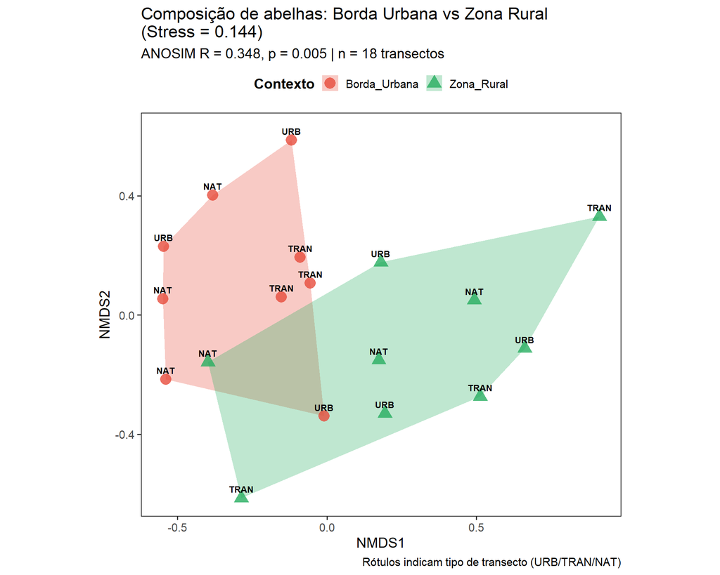

Figura 1: Composição de abelhas - Borda Urbana vs Zona Rural (n=18 transectos)

```r
hull_contexto <- nmds_scores %>%
  group_by(contexto) %>%
  slice(chull(NMDS1, NMDS2))

ggplot() +
  geom_polygon(data = hull_contexto,
               aes(x = NMDS1, y = NMDS2, fill = contexto, group = contexto),
               alpha = 0.3) +
  geom_point(data = nmds_scores,
             aes(x = NMDS1, y = NMDS2, color = contexto, shape = contexto),
             size = 5, alpha = 0.8) +
  geom_text(data = nmds_scores,
            aes(x = NMDS1, y = NMDS2, label = tipo_transecto),
            size = 3, fontface = "bold", color = "black",
            nudge_y = 0.03) +
  scale_fill_manual(values = c("Borda_Urbana" = "#E74C3C", "Zona_Rural" = "#27AE60"),
                    name = "Contexto") +
  scale_color_manual(values = c("Borda_Urbana" = "#E74C3C", "Zona_Rural" = "#27AE60"),
                     name = "Contexto") +
  scale_shape_manual(values = c(16, 17), name = "Contexto") +
  coord_equal() +
  theme_bw(base_size = 14) +
  theme(
    legend.position = "top",
    legend.title = element_text(face = "bold"),
    panel.grid = element_blank()
  ) +
  labs(
    x = "NMDS1", y = "NMDS2",
    title = paste0("Composição de abelhas: Borda Urbana vs Zona Rural\n(Stress = ",
                   round(nmds_transectos$stress, 3), ")"),
    subtitle = paste0("ANOSIM R = ", round(anosim_contexto$statistic, 3),
                      ", p = ", anosim_contexto$signif,
                      " | n = 18 transectos"),
    caption = "Rótulos indicam tipo de transecto (URB/TRAN/NAT)"
  )
```

## 5.3 Figura 2: NMDS por Tipo de Transecto

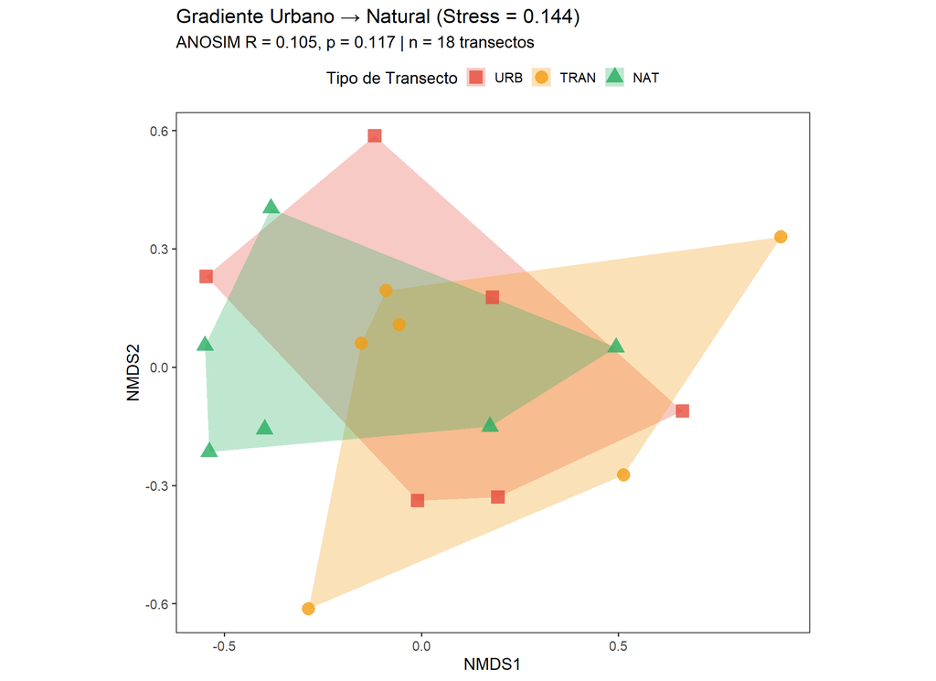

Figura 2: Gradiente urbano-natural (URB → TRAN → NAT)

```r
hull_transecto <- nmds_scores %>%
  group_by(tipo_transecto) %>%
  slice(chull(NMDS1, NMDS2))

cores_gradiente <- c("URB" = "#E74C3C", "TRAN" = "#F39C12", "NAT" = "#27AE60")

ggplot() +
  geom_polygon(data = hull_transecto,
               aes(x = NMDS1, y = NMDS2, fill = tipo_transecto, group = tipo_transecto),
               alpha = 0.3) +
  geom_point(data = nmds_scores,
             aes(x = NMDS1, y = NMDS2, color = tipo_transecto, shape = tipo_transecto),
             size = 5, alpha = 0.8) +
  scale_fill_manual(values = cores_gradiente, name = "Tipo de Transecto") +
  scale_color_manual(values = cores_gradiente, name = "Tipo de Transecto") +
  scale_shape_manual(values = c(15, 16, 17), name = "Tipo de Transecto") +
  coord_equal() +
  theme_bw(base_size = 14) +
  theme(
    legend.position = "top",
    panel.grid = element_blank()
  ) +
  labs(
    x = "NMDS1", y = "NMDS2",
    title = paste0("Gradiente Urbano → Natural (Stress = ", round(nmds_transectos$stress, 3), ")"),
    subtitle = paste0("ANOSIM R = ", round(anosim_transecto$statistic, 3),
                      ", p = ", anosim_transecto$signif,
                      " | n = 18 transectos")
  )
```

## 5.4 Figura 3: NMDS por Local

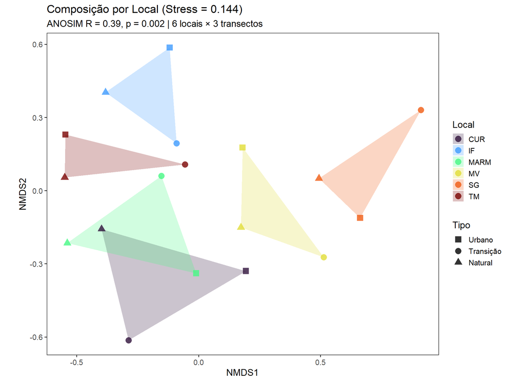

Figura 3: Composição por local de amostragem

```r
hull_local <- nmds_scores %>%
  group_by(Local) %>%
  slice(chull(NMDS1, NMDS2))

ggplot() +
  geom_polygon(data = hull_local,
               aes(x = NMDS1, y = NMDS2, fill = Local, group = Local),
               alpha = 0.25) +
  geom_point(data = nmds_scores,
             aes(x = NMDS1, y = NMDS2, color = Local, shape = tipo_transecto),
             size = 4, alpha = 0.8) +
  scale_fill_viridis_d(option = "turbo") +
  scale_color_viridis_d(option = "turbo") +
  scale_shape_manual(values = c(15, 16, 17),
                     name = "Tipo",
                     labels = c("Urbano", "Transição", "Natural")) +
  coord_equal() +
  theme_bw(base_size = 14) +
  theme(legend.position = "right", panel.grid = element_blank()) +
  labs(
    x = "NMDS1", y = "NMDS2",
    title = paste0("Composição por Local (Stress = ", round(nmds_transectos$stress, 3), ")"),
    subtitle = paste0("ANOSIM R = ", round(anosim_local$statistic, 3),
                      ", p = ", anosim_local$signif,
                      " | 6 locais × 3 transectos")
  )
```

## 5.5 Figura 4: Gradiente de Habitat Natural

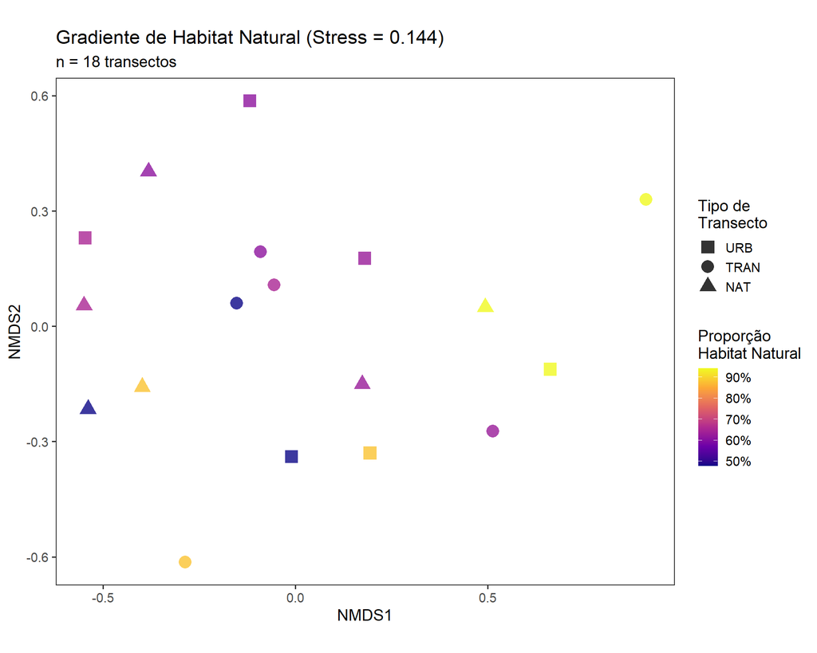

Figura 4: Gradiente de proporção de habitat natural

```r
ggplot(nmds_scores, aes(x = NMDS1, y = NMDS2, color = prop_hab_natural,
                        shape = tipo_transecto)) +
  geom_point(size = 5, alpha = 0.8) +
  scale_color_viridis_c(name = "Proporção\nHabitat Natural",
                        option = "plasma",
                        labels = scales::percent_format()) +
  scale_shape_manual(values = c(15, 16, 17), name = "Tipo de\nTransecto") +
  coord_equal() +
  theme_bw(base_size = 14) +
  theme(panel.grid = element_blank()) +
  labs(
    x = "NMDS1", y = "NMDS2",
    title = paste0("Gradiente de Habitat Natural (Stress = ",
                   round(nmds_transectos$stress, 3), ")"),
    subtitle = "n = 18 transectos"
  )
```

## 5.6 Figura 5: Vetores Ambientais (ENVFIT)

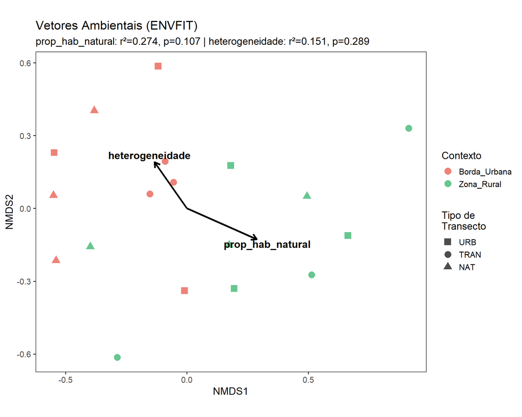

Figura 5: Vetores ambientais correlacionados com a ordenação

```r
envfit_coords <- as.data.frame(scores(envfit_resultado, "vectors")) * 0.6

ggplot() +
  geom_point(data = nmds_scores,
             aes(x = NMDS1, y = NMDS2, color = contexto, shape = tipo_transecto),
             size = 4, alpha = 0.7) +
  geom_segment(data = envfit_coords,
               aes(x = 0, y = 0, xend = NMDS1, yend = NMDS2),
               arrow = arrow(length = unit(0.3, "cm")),
               color = "black", size = 1.2) +
  geom_text(data = envfit_coords,
            aes(x = NMDS1 * 1.15, y = NMDS2 * 1.15, label = rownames(envfit_coords)),
            size = 5, fontface = "bold") +
  scale_color_manual(values = c("Borda_Urbana" = "#E74C3C", "Zona_Rural" = "#27AE60"),
                     name = "Contexto") +
  scale_shape_manual(values = c(15, 16, 17), name = "Tipo de\nTransecto") +
  coord_equal() +
  theme_bw(base_size = 14) +
  theme(panel.grid = element_blank()) +
  labs(
    x = "NMDS1",
    y = "NMDS2",
    title = "Vetores Ambientais (ENVFIT)",
    subtitle = paste0("prop_hab_natural: r²=", round(envfit_resultado$vectors$r[1], 3),
                      ", p=", round(envfit_resultado$vectors$pvals[1], 3),
                      " | heterogeneidade: r²=", round(envfit_resultado$vectors$r[2], 3),
                      ", p=", round(envfit_resultado$vectors$pvals[2], 3))
  )
```

## 5.7 Figura 6: ANOSIM Pairwise (Locais)

[figure not shown]

Figura 6: Diferenciação entre locais (ANOSIM pairwise)

```r
ggplot(pairwise_locais,
       aes(x = reorder(Comparacao, R_statistic), y = R_statistic,
           fill = p_adjusted < 0.05)) +
  geom_col() +
  geom_hline(yintercept = 0.5, linetype = "dashed", color = "red", size = 1) +
  geom_hline(yintercept = 0.25, linetype = "dotted", color = "orange", size = 0.8) +
  scale_fill_manual(
    values = c("TRUE" = "#27AE60", "FALSE" = "gray70"),
    labels = c("Significativo", "Não significativo"),
    name = "p-valor ajustado"
  ) +
  coord_flip() +
  theme_bw(base_size = 12) +
  labs(
    x = "Comparação entre Locais",
    y = "ANOSIM R statistic",
    title = "Diferenciação Par-a-Par entre Locais",
    subtitle = "Linha tracejada: R=0.5 (forte) | Linha pontilhada: R=0.25 (moderado)",
    caption = "p-valores ajustados por Bonferroni"
  )
```

## 5.8 Figura 7: Riqueza vs Habitat Natural

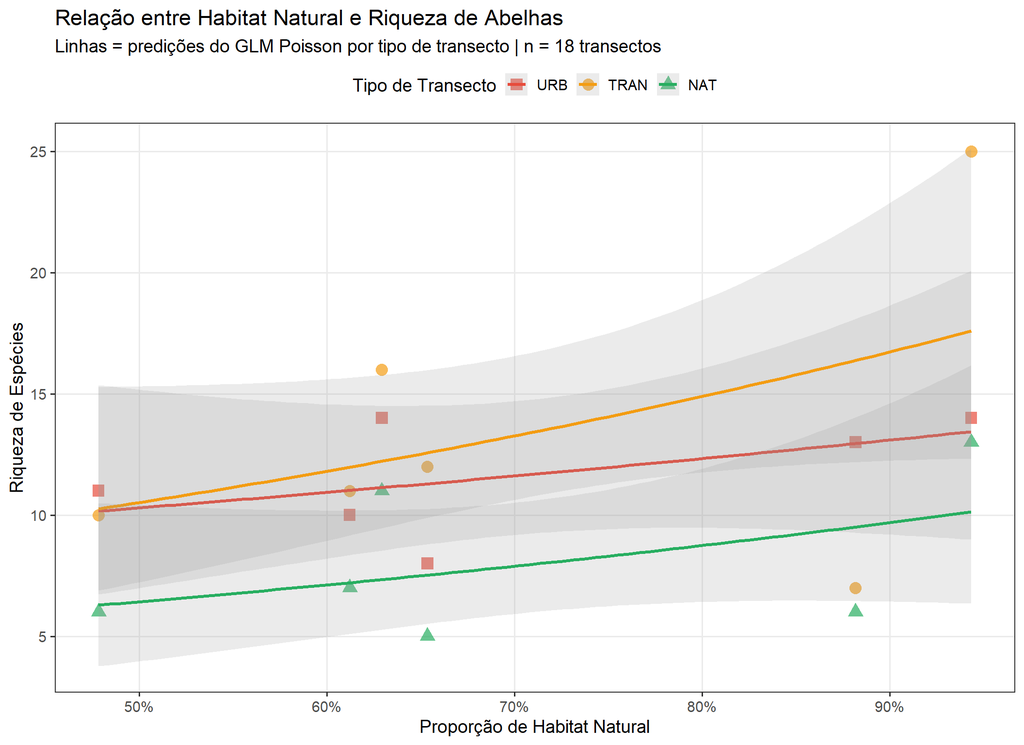

Figura 7: Relação entre riqueza e habitat natural por tipo de transecto

```r
ggplot(riqueza_por_transecto,
       aes(x = prop_hab_natural, y = riqueza, color = tipo_transecto, shape = tipo_transecto)) +
  geom_point(size = 4, alpha = 0.7) +
  geom_smooth(method = "glm", method.args = list(family = "poisson"),
              se = TRUE, linewidth = 1.2, alpha = 0.2) +
  scale_color_manual(values = cores_gradiente, name = "Tipo de Transecto") +
  scale_shape_manual(values = c(15, 16, 17), name = "Tipo de Transecto") +
  scale_x_continuous(labels = scales::percent_format()) +
  theme_bw(base_size = 14) +
  theme(
    legend.position = "top",
    panel.grid.minor = element_blank()
  ) +
  labs(
    x = "Proporção de Habitat Natural",
    y = "Riqueza de Espécies",
    title = "Relação entre Habitat Natural e Riqueza de Abelhas",
    subtitle = "Linhas = predições do GLM Poisson por tipo de transecto | n = 18 transectos"
  )
```

## 5.9 Figura 8: Riqueza por Contexto e Tipo de Transecto

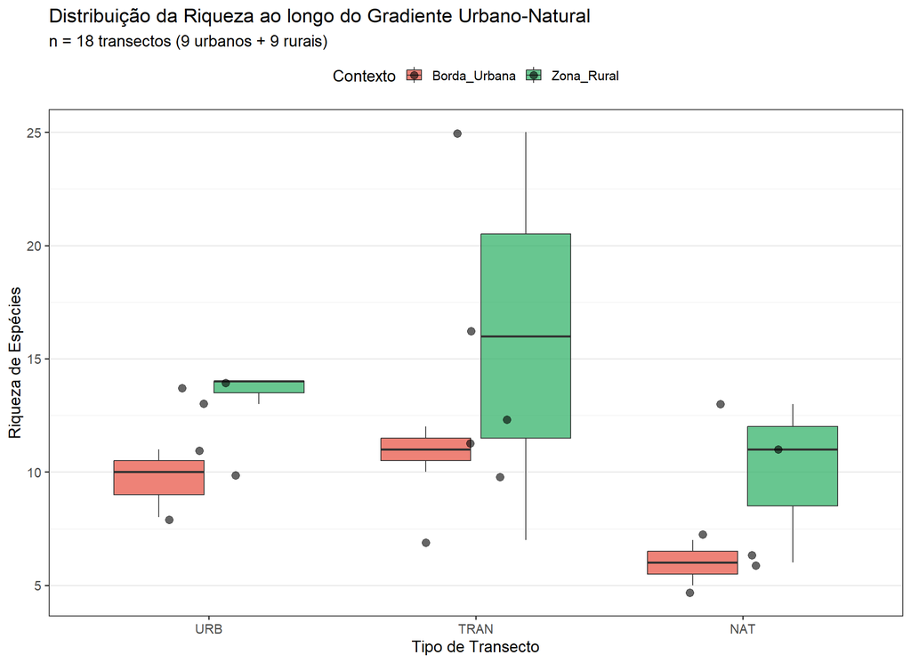

Figura 8: Distribuição da riqueza por contexto e tipo de transecto

```r
ggplot(riqueza_por_transecto,
       aes(x = tipo_transecto, y = riqueza, fill = contexto)) +
  geom_boxplot(alpha = 0.7, outlier.shape = NA) +
  geom_jitter(width = 0.2, alpha = 0.6, size = 3) +
  scale_fill_manual(values = c("Borda_Urbana" = "#E74C3C", "Zona_Rural" = "#27AE60"),
                    name = "Contexto") +
  theme_bw(base_size = 14) +
  theme(
    legend.position = "top",
    panel.grid.major.x = element_blank()
  ) +
  labs(
    x = "Tipo de Transecto",
    y = "Riqueza de Espécies",
    title = "Distribuição da Riqueza ao longo do Gradiente Urbano-Natural",
    subtitle = "n = 18 transectos (9 urbanos + 9 rurais)"
  )
```

## 5.10 Figura 9: Heterogeneidade vs Riqueza

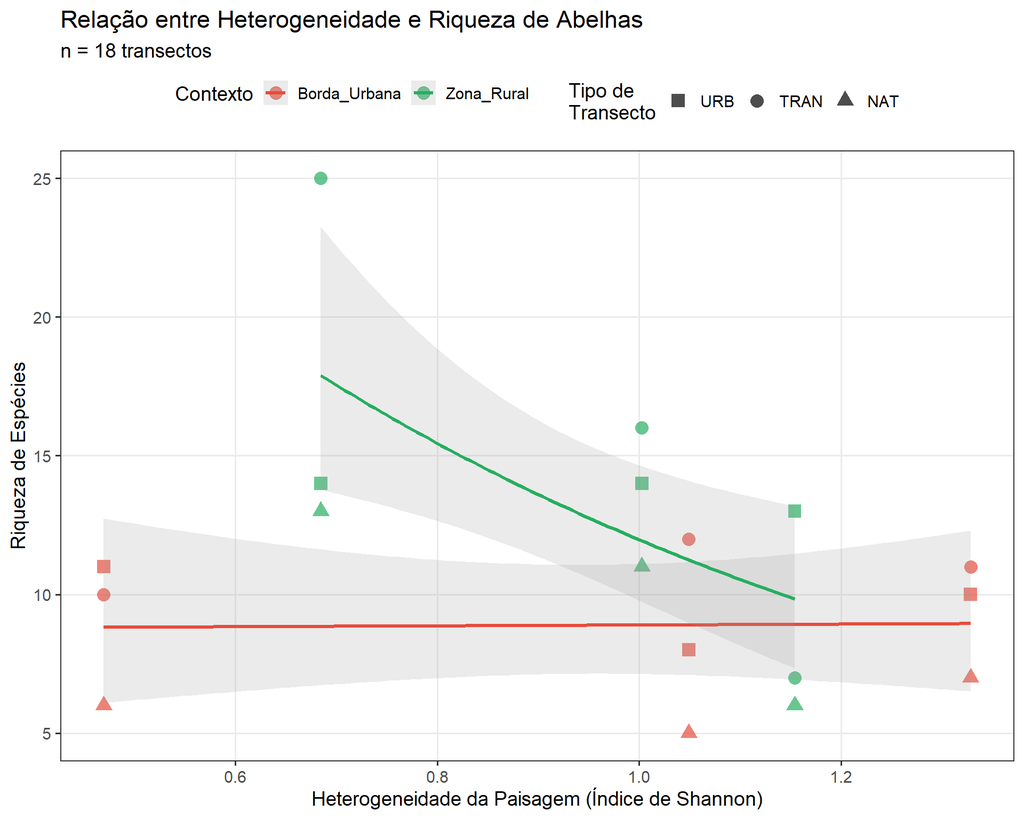

Figura 9: Relação entre heterogeneidade da paisagem e riqueza

```r
ggplot(riqueza_por_transecto,
       aes(x = heterogeneidade, y = riqueza, color = contexto, shape = tipo_transecto)) +
  geom_point(size = 4, alpha = 0.7) +
  geom_smooth(method = "glm", method.args = list(family = "poisson"),
              aes(group = contexto), se = TRUE, linewidth = 1.2, alpha = 0.2) +
  scale_color_manual(values = c("Borda_Urbana" = "#E74C3C", "Zona_Rural" = "#27AE60"),
                     name = "Contexto") +
  scale_shape_manual(values = c(15, 16, 17), name = "Tipo de\nTransecto") +
  theme_bw(base_size = 14) +
  theme(
    legend.position = "top",
    panel.grid.minor = element_blank()
  ) +
  labs(
    x = "Heterogeneidade da Paisagem (Índice de Shannon)",
    y = "Riqueza de Espécies",
    title = "Relação entre Heterogeneidade e Riqueza de Abelhas",
    subtitle = "n = 18 transectos"
  )
```

# 6 Tabela Resumo

```r
resumo_analises <- data.frame(
  Analise = c(
    "GLMM - Melhor modelo",
    "PERMANOVA - Habitat + Heterog",
    "PERMANOVA - + Tipo Transecto",
    "PERMANOVA - Gradiente URB-TRAN-NAT",
    "PERMANOVA - Habitat BLOQUEADA",
    "PERMANOVA - Gradiente BLOQUEADA",
    "ANOSIM - Borda vs Rural",
    "ANOSIM - Entre Locais",
    "ANOSIM - Gradiente URB-TRAN-NAT",
    "ENVFIT - Habitat Natural",
    "ENVFIT - Heterogeneidade"
  ),
  Estatistica = c(
    paste0("AICc = ", round(AICc(melhor_modelo), 1)),
    paste0("R² = ", round(perm1$R2[1], 3)),
    paste0("R² = ", round(perm3$R2[1], 3)),
    paste0("R² = ", round(perm4$R2[1], 3)),
    paste0("R² = ", round(perm_blocked$R2[1], 3)),
    paste0("R² = ", round(perm_gradiente_blocked$R2[1], 3)),
    paste0("R = ", round(anosim_contexto$statistic, 3)),
    paste0("R = ", round(anosim_local$statistic, 3)),
    paste0("R = ", round(anosim_transecto$statistic, 3)),
    paste0("r² = ", round(envfit_resultado$vectors$r[1], 3)),
    paste0("r² = ", round(envfit_resultado$vectors$r[2], 3))
  ),
  p_value = c(
    "—",
    round(perm1$`Pr(>F)`[1], 4),
    round(perm3$`Pr(>F)`[1], 4),
    round(perm4$`Pr(>F)`[1], 4),
    round(perm_blocked$`Pr(>F)`[1], 4),
    round(perm_gradiente_blocked$`Pr(>F)`[1], 4),
    round(anosim_contexto$signif, 4),
    round(anosim_local$signif, 4),
    round(anosim_transecto$signif, 4),
    round(envfit_resultado$vectors$pvals[1], 4),
    round(envfit_resultado$vectors$pvals[2], 4)
  ),
  stringsAsFactors = FALSE
)

knitr::kable(resumo_analises,
             caption = "Tabela 1: Resumo das análises estatísticas (n=18 transectos)",
             align = c("l", "c", "c"))
```

Tabela 1: Resumo das análises estatísticas (n=18 transectos)

| Analise | Estatistica | p_value |
| --- | --- | --- |
| GLMM - Melhor modelo | AICc = 103.7 | — |
| PERMANOVA - Habitat + Heterog | R² = 0.278 | 0.008 |
| PERMANOVA - + Tipo Transecto | R² = 0.464 | 0.001 |
| PERMANOVA - Gradiente URB-TRAN-NAT | R² = 0.187 | 0.093 |
| PERMANOVA - Habitat BLOQUEADA | R² = 0.278 | 1 |
| PERMANOVA - Gradiente BLOQUEADA | R² = 0.187 | 0.005 |
| ANOSIM - Borda vs Rural | R = 0.348 | 0.005 |
| ANOSIM - Entre Locais | R = 0.39 | 0.002 |
| ANOSIM - Gradiente URB-TRAN-NAT | R = 0.105 | 0.117 |
| ENVFIT - Habitat Natural | r² = 0.274 | 0.107 |
| ENVFIT - Heterogeneidade | r² = 0.151 | 0.289 |

# 7 Conclusões

## 7.1 Principais Resultados

### 7.1.1 ✅ Vantagens da Análise por Transectos (n=18)

1. **Evita pseudorreplicação**: Os 3 pontos dentro de cada transecto são tratados como uma única unidade amostral
2. **Estatisticamente mais correto**: Respeita a estrutura hierárquica dos dados
3. **Biologicamente interpretável**: Transectos representam gradientes reais (URB → TRAN → NAT)
4. **Controle adequado**: Efeito aleatório (1|Local) controla variação entre os 6 locais

### 7.1.2 📊 Resumo das Análises

#### 7.1.2.1 1. Diversidade Alfa (GLMM)

- **n = 18 transectos** (não 54 pontos)
- Melhor modelo selecionado via AICc
- Efeito aleatório de Local controla não-independência
- R² marginal = efeito apenas das variáveis ambientais
- R² condicional = variáveis + estrutura hierárquica

#### 7.1.2.2 2. Composição Beta

- **NMDS** (stress = 0.144): Qualidade da ordenação
- **PERMANOVA bloqueada**: Controla pseudorreplicação dos 3 transectos por local
- **ANOSIM**:
  - Contexto (Urbano vs Rural): R = 0.348
  - Gradiente (URB-TRAN-NAT): R = 0.105
  - Entre locais: R = 0.39

#### 7.1.2.3 3. Espécies Indicadoras

- **IndVal**: Espécies características de cada contexto/gradiente
- **SIMPER**: Espécies que mais contribuem para diferenças entre grupos

### 7.1.3 🔬 Interpretação Biológica

**Gradiente URB → TRAN → NAT:** - Representa um gradiente real de urbanização - ANOSIM pairwise mostra se as diferenças são graduais ou abruptas - Importante para entender zonas de transição

**Contexto (Urbano vs Rural):** - Diferenças em escala de paisagem - Relevante para conservação e manejo

### 7.1.4 📈 Figuras Geradas

1. ✅ NMDS por contexto (Urbano vs Rural)
2. ✅ NMDS por gradiente (URB-TRAN-NAT)
3. ✅ NMDS por local (6 locais × 3 transectos)
4. ✅ Gradiente de habitat natural
5. ✅ Vetores ambientais (ENVFIT)
6. ✅ ANOSIM pairwise entre locais
7. ✅ Riqueza vs habitat natural
8. ✅ Boxplot: Riqueza por contexto e transecto
9. ✅ Riqueza vs heterogeneidade

## 7.2 Comparação: 54 Pontos vs 18 Transectos

| Aspecto | 54 Pontos (❌) | 18 Transectos (✅) |
| --- | --- | --- |
| **n real** | Inflado | Correto |
| **Pseudorreplicação** | Presente | Controlada |
| **Interpretação** | Difícil | Clara |
| **Poder estatístico** | Falso | Real |
| **Publicável** | Questionável | Adequado |

## 7.3 Próximos Passos Sugeridos

1. 🔍 **Verificar pressupostos** dos modelos GLMM
2. 📊 **Explorar interações** entre variáveis (se biologicamente plausível)
3. 🐝 **Analisar grupos funcionais** (tamanho, sociabilidade, etc.)
4. 📝 **Preparar manuscrito** usando esta abordagem estatística correta

# 8 Informações da Sessão

**Análise realizada em:** 28/10/2025

**Unidade amostral:** 18 transectos (6 locais × 3 transectos)

**Contato:** cinthia.soares@ufvjm.edu.br

*Documento gerado com R Markdown*

**⚠️ IMPORTANTE:** Esta análise usa a estrutura hierárquica correta dos dados, evitando pseudorreplicação através da agregação por transectos e uso de modelos mistos.